# Supplemental Methods: anvi’o

```r
library(tidyverse)
library(ggtext)
library(ggh4x)
library(RColorBrewer)
library(viridis)
library(grid)
library(ggpubr)
library(gridtext)
library(kableExtra)
library(seqinr)
library(reshape2)
library(plotly)
library(htmlwidgets)
library(seqvisr)
```

This notebook contains analyses using anvi’o version 8 (Delmont and Eren, 2018; Eren et al., 2020) (development branch). For more in-depth information about anvi’o go to their official online site here: https://anvio.org/

# 1 Functional annotations

We use as input (`path_i`) the anvi’o contigs database files (`.db`) that were generated in SupplementalMethods_Prokka_Annotations.

## 1.1 COG annotation

First we downloaded and set up the NCBI’s Clusters of Orthologous Groups database Galperin et al. (2020) using `anvi-setup-ncbi-cogs`. The default is the latest version, which is COG20, meaning that anvi’o will use the NCBI’s 2020 release of COGs to setup the database.

The `anvi-run-ncbi-cogs` command was used to annotate the contig databases. We used DIAMOND as searching method (Buchfink et al., 2014) with the recommended “sensitive” option.

```bash
#conda activate anvio-dev

path_i="data/Anvio8/Contigs_db"

for file in $path_i/*.db; do
    anvi-run-ncbi-cogs -T 8 --search-with diamond -c $file;
done
```

## 1.2 KEGG annotation

First we downloaded and set up the KEGG KOfam (Kanehisa, 2000; Kanehisa et al., 2022) database using `anvi-setup-kegg-data`. We used the snapshot of the KEGG database dated 2023-09-22 (hash a2b5bde358bb). It contains 479 modules with 15116 entries.

The program `anvi-run-kegg-kofams` annotates genes in a given anvi’o contigs database with KEGG Orthology (KO) numbers via hits to the KEGG KOfam database. We used `-E` lower than 1e-15.

```bash
#conda activate anvio-dev

path_i="data/Anvio8/Contigs_db"

for file in $path_i/*.db; do
    anvi-run-kegg-kofams -T 8 --log-bitscores -E 1e-15 --just-do-it -c $file;
done
```

The option `--log-bitscores` records the bit scores values. They get saved to the main folder for the repo, so we moved them to a new subfolder

```r
path_i <- "."
path_o <- "data/Anvio8/KEGG_bitscores"
dir.create(file.path("data/Anvio8/KEGG_bitscores"), recursive = TRUE, showWarnings=FALSE)
files_to_move <- list.files(path_i, pattern = "_bitscores.txt$", full.names = TRUE)

for (file in files_to_move) {
  new_path <- file.path(path_o, basename(file))
  print(new_path)
  file.rename(file, new_path)
}
```

## 1.3 PFAM annotation

First you need to download and set up the PFAM database (Bateman, 2000; Mistry et al., 2020) using `anvi-setup-pfams`: this is something you will do only once. We used Pfam version 36.0 (2023-07).

```bash
#conda activate anvio-dev

path_i="data/Anvio8/Contigs_db"

for file in $path_i/*.db; do
    anvi-run-pfams -T 8 -c $file;
done
```

## 1.4 Running HMMs

When you run the following command the occurrence of bacterial single-copy genes across your contigs is added to your contigs database (Eddy, 2011).

```bash
#conda activate anvio-dev

path_i="data/Anvio8/Contigs_db"

for file in $path_i/*.db; do
    anvi-run-hmms -T 8 -c $file --just-do-it;
done
```

## 1.5 Running CAZyme

The program `anvi-run-cazymes` annotates genes in your contigs-db with the dbCAN CAZyme database.

```bash
#conda activate anvio-dev

path_i="data/Anvio8/Contigs_db"

for file in $path_i/*.db; do
    anvi-run-cazymes -T 8 -c $file;
done
```

## 1.6 Annotation Summaries

This generates basic stats on the annotations:

```bash
#conda activate anvio-dev

path_i="data/Anvio8/Contigs_db"
path_o="data/Anvio8/Annotation_summaries"
mkdir -p "$path_o"

for file in $path_i/*.db; do
    FILENAME=`basename ${file%.*}`
    anvi-display-contigs-stats $file --report-as-text -o $path_o/stats_$FILENAME.txt;
done
```

This provides basic info on the contigs databases:

```bash
#conda activate anvio-dev

path_i="data/Anvio8/Contigs_db"
path_o="data/Anvio8/Annotation_summaries"

for file in $path_i/*.db; do
    anvi-db-info $file &>> $path_o/anvi-db-info_log.txt;
done
```

# 2 Pangenome Analysis

## 2.1 Generating an anvi’o genomes storage database

The program `anvi-gen-genomes-storage` requires a `.txt` file with the names and path locations of the genomes to be included in the genome storage database. The storage database generated with `CorPGA_Anvio_GenomeList_v01a.txt` includes the 104 *Corynebacterium* genomes selected for pangenomic analysis (The three *C. macginleyi* genomes were excluded).

```bash
#conda activate anvio-dev

path_i="data/Anvio8/Pangenomic_Analysis"
mkdir -p "$path_i"

anvi-gen-genomes-storage -e "data/genome_lists/CorPGA_Anvio_GenomeList_v01a.txt" -o $path_i/CorPGA-All4Cor-GENOMES.db --gene-caller Prodigal
```

This provides basic info on the generated genomes storage database:

```bash
#conda activate anvio-dev

anvi-db-info $path_i/CorPGA-All4Cor-GENOMES.db
```

## 2.2 Running the pangenomic analyses

In order to analyze the pangenome individually for each of the four *Corynebacterium* species we created a `.txt` file including the list of genomes for each species and ran `anvi-pan-genome` with the `-G` flag:

```bash
#conda activate anvio-dev

path_i="data/Anvio8/Pangenomic_Analysis"
path_g="data/genome_lists"

anvi-pan-genome -g $path_i/CorPGA-All4Cor-GENOMES.db \
                -G $path_g/CorPGA_Anvio_GenomeList_PangenomeCpr.txt \
                -o $path_i/Only_Cpr -n PAN_Cpr \
                --use-ncbi-blast --mcl-inflation 10  --num-threads 8

anvi-pan-genome -g $path_i/CorPGA-All4Cor-GENOMES.db \
                -G $path_g/CorPGA_Anvio_GenomeList_PangenomeCps.txt \
                -o $path_i/Only_Cps -n PAN_Cps \
                --use-ncbi-blast --mcl-inflation 10  --num-threads 8

anvi-pan-genome -g $path_i/CorPGA-All4Cor-GENOMES.db \
                -G $path_g/CorPGA_Anvio_GenomeList_PangenomeCac.txt \
                -o $path_i/Only_Cac -n PAN_Cac \
                --use-ncbi-blast --mcl-inflation 10  --num-threads 8

anvi-pan-genome -g $path_i/CorPGA-All4Cor-GENOMES.db \
                -G $path_g/CorPGA_Anvio_GenomeList_PangenomeCtu.txt \
                -o $path_i/Only_Ctu -n PAN_Ctu \
                --use-ncbi-blast --mcl-inflation 10  --num-threads 8
```

## 2.3 Displaying the pangenomes

This will display the pangenome in your default internet browser. Anvi’o says google chrome is the most compatible with the anvi’o interactive interface. You need to pick one of the `-p` inputs for each PAN.db file:

```bash
#conda activate anvio-dev

path_i="data/Anvio8/Pangenomic_Analysis"

anvi-display-pan -p $path_i/Only_Cpr/PAN_Cpr-PAN.db -g $path_i/CorPGA-All4Cor-GENOMES.db

anvi-display-pan -p $path_i/Only_Cps/PAN_Cps-PAN.db -g $path_i/CorPGA-All4Cor-GENOMES.db

anvi-display-pan -p $path_i/Only_Cac/PAN_Cac-PAN.db -g $path_i/CorPGA-All4Cor-GENOMES.db

anvi-display-pan -p $path_i/Only_Ctu/PAN_Ctu-PAN.db -g $path_i/CorPGA-All4Cor-GENOMES.db
```

If you are using Windows and it cannot display the interactive page then try copy and pasting either 127.0.0.1:8080 or http://localhost:8080/ into your browser. Do not use sudo in the front of the command either.

Once it opens in the browser, you can adjust image settings and click the “DRAW” icon to view it. For help using the interactive interface see http://merenlab.org/2016/02/27/the-anvio-interactive-interface/

We manually reordered the layers to match the phylogenomic trees per species using the click and drag option on the interactive interface. The order names is inverse to the layers in the concentric diagram. When all the layers were re-ordered to match the phylogenomic tree we clicked the draw button and saved the svg file.

## 2.4 Creating bin collections

### 2.4.1 Core vs. Accessory

In order to define the Core vs Accessory pangenome for each of the four species level pangenomes we use anvi’o interactive interface. In the “Bins” tab we created the corresponding bins. Using the “Search” tab we used “Search gene clusters using filters” and “Append splits to selected bin” to create bins. The following tables summarizes how the bins in the collection named **CorevsAccessory** were created (last column indicates the criteria used on each search):

#### 2.4.1.1 *C. propinquum* pangenome

| Pangenome Bin | # of Gene Clusters/Pangenome | Percentage | Gene Cluster occurs in # of genomes |
| --- | --- | --- | --- |
| Core | 1824/3108 | 58.7% | 19 |
| Single Copy Core | 1715/3108 | 55.2% | 19 |
| Multicopy Core | 109/3108 | 3.5% | 19 |
| Soft Core | 39/3108 | 1.3% | 18 |
| Shell | 689/3108 | 22.2% | 3-17 |
| Cloud | 556/3108 | 17.9% | 1-2 |

#### 2.4.1.2 *C. pseudodiphtheriticum* pangenome

| Pangenome Bin | # of Gene Clusters/Pangenome | Percentage | Gene Cluster occurs in # of genomes |
| --- | --- | --- | --- |
| Core | 1714/3590 | 47.7% | 43 |
| Single Copy Core | 1488/3590 | 41.4% | 43 |
| Multicopy Core | 226/3590 | 6.3% | 43 |
| Soft Core | 46/3590 | 1.3% | 40-42 |
| Shell | 972/3590 | 27.1% | 3-39 |
| Cloud | 858/3590 | 23.9% | 1-2 |

#### 2.4.1.3 *C. accolens* pangenome

| Pangenome Bin | # of Gene Clusters/Pangenome | Percentage | Gene Cluster occurs in # of genomes |
| --- | --- | --- | --- |
| Core | 1904/3427 | 55.6% | 34 |
| Single Copy Core | 1734/3427 | 50.6% | 34 |
| Multicopy Core | 170/3427 | 5% | 34 |
| Soft Core | 77/3427 | 2.2% | 32-33 |
| Shell | 676/3427 | 19.7% | 3-31 |
| Cloud | 770/3427 | 22.5% | 1-2 |

#### 2.4.1.4 *C. tuberculostearicum* pangenome

[output not shown]

### 2.4.2 PPanGGOLiN Partitions

PPanGGOLiN partitions were imported as a collection of bins named **PPanGGOLiNpartitions** as described in [PPanGGOLiN analysis](https://klemonlab.github.io/CorPGA_Pangenomics/SupplementalMethods_PPanGGOLiN.html).

## 2.5 Summarizing the pangenome files

Using the program `anvi-summarize` we exported summary tables for each of the four species level pangenomes.

The resulting summaries contain a `gene_clusters_summary.txt.gz` file that links each gene to gene clusters, genomes, functions, layers, and bins selected from the interface. We used the flag `-C` to selected the **CorevsAccessory** collection described above:

```bash
#conda activate anvio-dev

path_i="data/Anvio8/Pangenomic_Analysis"

anvi-summarize -p $path_i/Only_Cpr/PAN_Cpr-PAN.db \
               -g $path_i/CorPGA-All4Cor-GENOMES.db \
               -o $path_i/Only_Cpr/Summaries \
               -C CorevsAccessory

anvi-summarize -p $path_i/Only_Cps/PAN_Cps-PAN.db \
               -g $path_i/CorPGA-All4Cor-GENOMES.db \
               -o $path_i/Only_Cps/Summaries \
               -C CorevsAccessory

anvi-summarize -p $path_i/Only_Cac/PAN_Cac-PAN.db \
               -g $path_i/CorPGA-All4Cor-GENOMES.db \
               -o $path_i/Only_Cac/Summaries \
               -C CorevsAccessory

anvi-summarize -p $path_i/Only_Ctu/PAN_Ctu-PAN.db \
               -g $path_i/CorPGA-All4Cor-GENOMES.db \
               -o $path_i/Only_Ctu/Summaries \
               -C CorevsAccessory
```

The output files were used for the COG functional analysis based on PPanGGOLiN partitions.

# 3 KEGG Metabolic Analysis

## 3.1 Estimation of KEGG module completeness

Using `anvi-estimate-metabolism` we predicted KEGG module completeness as described in (Veseli et al., 2023) for the the organisms listed in `CorPGA_MetabolicAnalysis_GenomeList_v01.txt`. This list includes:

- The 102 *Corynebacterium* genomes selected for metabolic analysis (Cac_ATCC_49726 & Cps_090104 were excluded for this analysis, as well as all three *C. macginleyi* genomes)
- Plus 27 for the 28 *Dolosigranulum pigrum* genomes described in (Flores Ramos et al., 2021) (KPL3086 was not included in the analysis due to being highly similar to KPL3065).
- As well as the 9 reference genomes with original NCBI annotations listed in **Table S3D**.

We generated outputs both in long tabular and matrix format with the KO hits and KEGG modules completeness scores.

```bash
#conda activate anvio-dev

mkdir -p "data/Anvio8/Metabolic_Analysis"
path_o="data/Anvio8/Metabolic_Analysis"

txt_file="data/genome_lists/CorPGA_MetabolicAnalysis_GenomeList_v01.txt"
prefix=CorPGA
path_o="data/Anvio8/Metabolic_Analysis"
mkdir -p "$path_o"

anvi-estimate-metabolism -e $txt_file \
                         -O $path_o/$prefix --matrix-format --include-metadata

anvi-estimate-metabolism -e $txt_file \
                         -O $path_o/$prefix --add-copy-number --output-modes modules,module_paths,module_steps,hits
```

## 3.2 Module Enrichment Analysis

The `CorPGA_modules.txt` file generated in the previous step is used by `anvi-compute-metabolic-enrichment` to calculate KEGG module enrichment (Shaiber et al., 2020) across different groups of genomes. Enrichment was explored across different genome groupings as described in the following files:

```bash
#conda activate anvio-dev

csv_file_modules="data/Anvio8/Metabolic_Analysis/CorPGA_modules.txt"
path_o="data/Anvio8/Metabolic_Analysis/Enrichment_Modules"
mkdir -p "$path_o"

txt_file_groups="data/genome_lists/CorPGA_MetabolicAnalysis_Groups_4Cor.txt"
output_file="$path_o/CorPGA_enriched_modules_stepwise_1_4Cor.txt"
anvi-compute-metabolic-enrichment -M "$csv_file_modules" \
                                  -G "$txt_file_groups" \
                                  -o "$output_file" \
                                  --use-stepwise-completeness \
                                  --module-completion-threshold 1.0

txt_file_groups="data/genome_lists/CorPGA_MetabolicAnalysis_Groups_CorDpi.txt"
output_file="$path_o/CorPGA_enriched_modules_stepwise_1_CorDpi.txt"
anvi-compute-metabolic-enrichment -M "$csv_file_modules" \
                                  -G "$txt_file_groups" \
                                  -o "$output_file" \
                                  --use-stepwise-completeness \
                                  --module-completion-threshold 1.0

txt_file_groups="data/genome_lists/CorPGA_MetabolicAnalysis_Groups_Cps.txt"
output_file="$path_o/CorPGA_enriched_modules_stepwise_1_Cps.txt"
anvi-compute-metabolic-enrichment -M "$csv_file_modules" \
                                  -G "$txt_file_groups" \
                                  -o "$output_file" \
                                  --use-stepwise-completeness \
                                  --module-completion-threshold 1.0

txt_file_groups="data/genome_lists/CorPGA_MetabolicAnalysis_Groups_References.txt"
output_file="$path_o/CorPGA_enriched_modules_stepwise_1_References.txt"
anvi-compute-metabolic-enrichment -M "$csv_file_modules" \
                                  -G "$txt_file_groups" \
                                  -o "$output_file" \
                                  --use-stepwise-completeness \
                                  --module-completion-threshold 1.0
```

## 3.3 KO Enrichment Analysis

We used `anvi-display-functions` to perform this functional enrichment (Shaiber et al., 2020). It runs the enrichment for the desired annotations (in this case KOfam). It saves the output to a system temp file that was recovered, renamed and saved into the same `path_o` along with the database file.

The same files where used to indicate grouping options equivalent to the ones used for the enrichment at the module level:

```bash
#conda activate anvio-dev

txt_file="data/genome_lists/CorPGA_MetabolicAnalysis_GenomeList_v01.txt"
path_o="data/Anvio8/Metabolic_Analysis/Enrichment_KOs"
mkdir -p "$path_o"

txt_file_groups="data/genome_lists/CorPGA_MetabolicAnalysis_Groups_4Cor.txt"
anvi-display-functions -e $txt_file \
                       --groups-txt $txt_file_groups \
                       --annotation-source KOfam \
                       --profile-db $path_o/KOfam_4Cor.db

txt_file_groups="data/genome_lists/CorPGA_MetabolicAnalysis_Groups_CorDpi.txt"
anvi-display-functions -e $txt_file \
                       --groups-txt $txt_file_groups \
                       --annotation-source KOfam \
                       --profile-db $path_o/KOfam_CorDpi.db

txt_file_groups="data/genome_lists/CorPGA_MetabolicAnalysis_Groups_Cps.txt"
anvi-display-functions -e $txt_file \
                       --groups-txt $txt_file_groups \
                       --annotation-source KOfam \
                       --profile-db $path_o/KOfam_Cps.db

txt_file_groups="data/genome_lists/CorPGA_MetabolicAnalysis_Groups_References.txt"
anvi-display-functions -e $txt_file \
                       --groups-txt $txt_file_groups \
                       --annotation-source KOfam \
                       --profile-db $path_o/KOfam_References.db
```

This generates a list of all enriched KOs, including KOs that belong to already identified enriched modules. We are interested in identifying other KOs, other than the ones identified by studying the modules output. The next function filters out KOs that are part of the definition of modules listed in the enriched modules output.

```r
get_KOs_not_in_enrich_modules <- function(modules, hits, enrich_modules, enrich_KOs, q_value_threshold) {

  # Get list of KOs that correspond with the modules on the enrichment file
  modules_subset <- modules %>% filter(module %in% enrich_modules$accession)
  module_definition_subset <- paste(modules_subset$module_definition, collapse = " ")
  module_definition_subset <- str_extract_all(module_definition_subset, "\\bK\\d+\\b")
  module_definition_subset <- unique(unlist(module_definition_subset))

  # Add a column to enrich_KOs indicating if the KO is the previous list
  enrich_KOs$inModule <- sapply(strsplit(as.character(enrich_KOs$accession), ","), function(x) all((x %in% module_definition_subset)))

  # Filter Enrich_KO based on inModule and q_value_threshold
  enrich_KOs_filtered <- enrich_KOs %>%
    filter(inModule == FALSE) %>%
    filter(adjusted_q_value < q_value_threshold)

  return(enrich_KOs_filtered)
}

Modules <- read_delim("data/Anvio8/Metabolic_Analysis/CorPGA_modules.txt", show_col_types = FALSE, col_types = cols(unique_enzymes_hit_counts = col_character(), gene_caller_ids_in_module = col_character()))
KOHits <- read_delim("data/Anvio8/Metabolic_Analysis/CorPGA_hits.txt", show_col_types = FALSE)

Enrich_Mod_4Cor <- read_delim("data/Anvio8/Metabolic_Analysis/Enrichment_Modules/CorPGA_enriched_modules_stepwise_1_4Cor.txt", show_col_types = FALSE)
Enrich_KO_4Cor <- read_delim("data/Anvio8/Metabolic_Analysis/Enrichment_KOs/CorPGA_enriched_KOs_4Cor.txt", show_col_types = FALSE)
Enrich_KO_4Cor_Filtered <- get_KOs_not_in_enrich_modules(Modules, KOHits, Enrich_Mod_4Cor, Enrich_KO_4Cor, 0.1)
write_csv(Enrich_KO_4Cor_Filtered, "data/Anvio8/Metabolic_Analysis/Enrichment_KOs/CorPGA_enriched_KOs_4Cor_Filtered.csv")

Enrich_Mod_CorDpi <- read_delim("data/Anvio8/Metabolic_Analysis/Enrichment_Modules/CorPGA_enriched_modules_stepwise_1_CorDpi.txt", show_col_types = FALSE)
Enrich_KO_CorDpi <- read_delim("data/Anvio8/Metabolic_Analysis/Enrichment_KOs/CorPGA_enriched_KOs_CorDpi.txt", show_col_types = FALSE)
Enrich_KO_CorDpi_Filtered <- get_KOs_not_in_enrich_modules(Modules, KOHits, Enrich_Mod_CorDpi, Enrich_KO_CorDpi, 0.1)
write_csv(Enrich_KO_CorDpi_Filtered, "data/Anvio8/Metabolic_Analysis/Enrichment_KOs/CorPGA_enriched_KOs_CorDpi_Filtered.csv")

Enrich_Mod_Cps <- read_delim("data/Anvio8/Metabolic_Analysis/Enrichment_Modules/CorPGA_enriched_modules_stepwise_1_Cps.txt", show_col_types = FALSE)
Enrich_KO_Cps <- read_delim("data/Anvio8/Metabolic_Analysis/Enrichment_KOs/CorPGA_enriched_KOs_Cps.txt", show_col_types = FALSE)
Enrich_KO_Cps_Filtered <- get_KOs_not_in_enrich_modules(Modules, KOHits, Enrich_Mod_Cps, Enrich_KO_Cps, 0.1)
write_csv(Enrich_KO_Cps_Filtered, "data/Anvio8/Metabolic_Analysis/Enrichment_KOs/CorPGA_enriched_KOs_Cps_Filtered.csv")

Enrich_Mod_References <- read_delim("data/Anvio8/Metabolic_Analysis/Enrichment_Modules/CorPGA_enriched_modules_stepwise_1_References.txt", show_col_types = FALSE)
Enrich_KO_References <- read_delim("data/Anvio8/Metabolic_Analysis/Enrichment_KOs/CorPGA_enriched_KOs_References.txt", show_col_types = FALSE)
Enrich_KO_References_Filtered <- get_KOs_not_in_enrich_modules(Modules, KOHits, Enrich_Mod_References, Enrich_KO_References, 0.1)
write_csv(Enrich_KO_References_Filtered, "data/Anvio8/Metabolic_Analysis/Enrichment_KOs/CorPGA_enriched_KOs_References_Filtered.csv")
```

## 3.4 Figures and Tables

### 3.4.1 Tables S3 and S4

From the output files generated by `anvi-estimate-metabolism` we include as Supplemental data the following tables:

- **TableS3A. KO hits:** Corresponds to output file `CorPGA_hits.txt` and contains individual KO annotations for all genomes.
- **TableS4A. KEEG modules:** Corresponds to output file `CorPGA_modules.txt` and contains KEGG module estimations for all genomes in a long format dataframe.
- **TableS4B. KEGG module stepwise matrix:** Corresponds to output file `CorPGA-module_stepwise_completeness-MATRIX.txt` and contains KEGG module stepwise completion score for all genomes in a wide format dataframe (rows are modules, numeric columns are strains).
- **TableS4C. KEGG modules by Species:** The following code was used to read the previous table and generate a version with stepwise module completeness averaged by species (rows are modules, numeric columns are species):

```r
Modules_MatrixbyGenome <- read_delim("data/Anvio8/Metabolic_Analysis/CorPGA-module_stepwise_completeness-MATRIX.txt")

# Identify numerical and non-numerical columns
numeric_cols <- sapply(Modules_MatrixbyGenome, is.numeric)
non_numeric_cols <- names(Modules_MatrixbyGenome)[!numeric_cols]

# Extract unique prefixes (based on strain name including species name) from numerical column names
prefixes <- unique(sub("_.*", "", names(Modules_MatrixbyGenome)[numeric_cols]))

# Define function to calculate row-wise means for columns with the same prefix
calculate_prefix_means <- function(df, prefix) {
  df %>%
    select(starts_with(prefix)) %>%
    rowMeans(na.rm = TRUE) %>%
    round(2)
}

# Calculate the row-wise means for each prefix and bind them into a new data frame
averaged_df <- map_dfc(prefixes, ~ {
  tibble(!! .x := calculate_prefix_means(Modules_MatrixbyGenome, .x))
})

# Combine the non-numerical columns and the averaged columns by species
Modules_MatrixbySpecies <- bind_cols(Modules_MatrixbyGenome %>% select(all_of(non_numeric_cols)), averaged_df)

write.csv(Modules_MatrixbySpecies, "data/Anvio8/Metabolic_Analysis/Fig_Tables/CorPGA-module_stepwise_completeness-MATRIXbySpecies.csv", row.names = F)
```

As described above, metabolic enrichment was explored across different genome groupings, however only the analysis comparing the 4 nasal *Corynebacterium* as defined in `CorPGA_MetabolicAnalysis_Groups_4Cor.txt` was included in the final manuscript. We include the following tables:

- **TableS4D. Enriched_Modules_4Cor:** Corresponds to the output file from `anvi-compute-metabolic-enrichment`
- **TableS3B. OtherEnriched_KOs_4Cor:** Corresponds to the output file `CorPGA_enriched_KOs_4Cor_Filtered.csv`. Includes only the enriched KOs that are not part of any module already described in tab A.

### 3.4.2 Figure 4

```r
# Read modules data and select only the genomes for the four nasal Corynebacterium species and Dolosigranulum pigrum. Make appropriate labeling columns
Modules <- read_delim("data/Anvio8/Metabolic_Analysis/CorPGA_modules.txt", show_col_types = FALSE, col_types = cols(unique_enzymes_hit_counts = col_character(), gene_caller_ids_in_module = col_character())) %>%
  filter(!grepl("^GCF", genome_name)) %>%
  mutate(module_class_short = paste0("(", substr(module_class, 1, 1), ")")) %>%
  mutate(species_name = str_extract(genome_name, "^[^_]+")) %>%
  unite(modules_label, c(module_class_short, module_category, module_subcategory), sep = "_", remove = FALSE) %>%
  mutate_at(c("species_name", "genome_name", "module", "module_name", "module_category", "module_subcategory", "module_class", "modules_label"), factor)

# Summary tally table of fully stepwise complete modules by species
ModulesTable <- Modules %>%
  filter(stepwise_module_completeness == 1) %>%
  group_by(module_category, module_subcategory, module, module_name, species_name) %>%
  tally()

# Table converted to wide and percentages calculated based on number of genomes per species
ModulesTableWide <- ModulesTable %>%
  pivot_wider(names_from = species_name, values_from = n, values_fill = 0)

ModulesTableWide$Cpr = round(100*(ModulesTableWide$Cpr/19), 1)
ModulesTableWide$Cps = round(100*(ModulesTableWide$Cps/42), 1)
ModulesTableWide$Cac = round(100*(ModulesTableWide$Cac/33), 1)
ModulesTableWide$Ctu = round(100*(ModulesTableWide$Ctu/8), 1)
ModulesTableWide$Dpi = round(100*(ModulesTableWide$Dpi/27), 1)

# Modules with less than 12.5% across all species eliminated
ModulesTableWide <- ModulesTableWide %>%
  select(module_category, module_subcategory, module, module_name, Cpr, Cps, Cac, Ctu, Dpi) %>%
  filter(rowSums(across(c(Cpr, Cps, Cac, Ctu, Dpi)) > 12.5) > 0)

# Version of the table to calculate the percentage of complete modules across the four Corynebacterium species:
ModulesData <- ModulesTable %>%
  filter(species_name != "Dpi") %>%
  group_by(module_category, module_subcategory, module, module_name) %>%
  summarise(total = sum(n)) %>%
  mutate(percent = 100*total/102)

write_csv(ModulesTableWide, "data/Anvio8/Metabolic_Analysis/Fig_Tables/TableKEGG.csv")
kable(ModulesTableWide)
```

| module_category | module_subcategory | module | module_name | Cpr | Cps | Cac | Ctu | Dpi |
| --- | --- | --- | --- | --- | --- | --- | --- | --- |
| Amino acid metabolism | Arginine and proline metabolism | M00015 | Proline biosynthesis, glutamate => proline | 100.0 | 100.0 | 100.0 | 100.0 | 0.0 |
| Amino acid metabolism | Arginine and proline metabolism | M00028 | Ornithine biosynthesis, glutamate => ornithine | 100.0 | 100.0 | 100.0 | 50.0 | 0.0 |
| Amino acid metabolism | Arginine and proline metabolism | M00844 | Arginine biosynthesis, ornithine => arginine | 100.0 | 100.0 | 100.0 | 100.0 | 0.0 |
| Amino acid metabolism | Arginine and proline metabolism | M00970 | Proline degradation, proline => glutamate | 100.0 | 100.0 | 100.0 | 100.0 | 0.0 |
| Amino acid metabolism | Aromatic amino acid metabolism | M00022 | Shikimate pathway, phosphoenolpyruvate + erythrose-4P => chorismate | 100.0 | 100.0 | 100.0 | 100.0 | 0.0 |
| Amino acid metabolism | Aromatic amino acid metabolism | M00023 | Tryptophan biosynthesis, chorismate => tryptophan | 100.0 | 100.0 | 100.0 | 100.0 | 0.0 |
| Amino acid metabolism | Branched-chain amino acid metabolism | M00019 | Valine/isoleucine biosynthesis, pyruvate => valine / 2-oxobutanoate => isoleucine | 100.0 | 100.0 | 100.0 | 100.0 | 0.0 |
| Amino acid metabolism | Branched-chain amino acid metabolism | M00432 | Leucine biosynthesis, 2-oxoisovalerate => 2-oxoisocaproate | 100.0 | 100.0 | 100.0 | 100.0 | 0.0 |
| Amino acid metabolism | Branched-chain amino acid metabolism | M00570 | Isoleucine biosynthesis, threonine => 2-oxobutanoate => isoleucine | 100.0 | 100.0 | 100.0 | 100.0 | 0.0 |
| Amino acid metabolism | Cysteine and methionine metabolism | M00017 | Methionine biosynthesis, aspartate => homoserine => methionine | 100.0 | 100.0 | 100.0 | 100.0 | 0.0 |
| Amino acid metabolism | Cysteine and methionine metabolism | M00021 | Cysteine biosynthesis, serine => cysteine | 100.0 | 100.0 | 100.0 | 100.0 | 0.0 |
| Amino acid metabolism | Histidine metabolism | M00026 | Histidine biosynthesis, PRPP => histidine | 100.0 | 100.0 | 90.9 | 0.0 | 0.0 |
| Amino acid metabolism | Histidine metabolism | M00045 | Histidine degradation, histidine => N-formiminoglutamate => glutamate | 100.0 | 100.0 | 100.0 | 100.0 | 0.0 |
| Amino acid metabolism | Lysine metabolism | M00016 | Lysine biosynthesis, succinyl-DAP pathway, aspartate => lysine | 100.0 | 100.0 | 100.0 | 50.0 | 0.0 |
| Amino acid metabolism | Serine and threonine metabolism | M00018 | Threonine biosynthesis, aspartate => homoserine => threonine | 100.0 | 100.0 | 100.0 | 100.0 | 81.5 |
| Amino acid metabolism | Serine and threonine metabolism | M00020 | Serine biosynthesis, glycerate-3P => serine | 100.0 | 100.0 | 100.0 | 87.5 | 0.0 |
| Amino acid metabolism | Serine and threonine metabolism | M00621 | Glycine cleavage system | 0.0 | 0.0 | 100.0 | 100.0 | 100.0 |
| Biosynthesis of terpenoids and polyketides | Polyketide sugar unit biosynthesis | M00793 | dTDP-L-rhamnose biosynthesis | 100.0 | 100.0 | 100.0 | 100.0 | 0.0 |
| Biosynthesis of terpenoids and polyketides | Terpenoid backbone biosynthesis | M00096 | C5 isoprenoid biosynthesis, non-mevalonate pathway | 0.0 | 0.0 | 100.0 | 100.0 | 0.0 |
| Biosynthesis of terpenoids and polyketides | Terpenoid backbone biosynthesis | M00364 | C10-C20 isoprenoid biosynthesis, bacteria | 0.0 | 0.0 | 100.0 | 100.0 | 0.0 |
| Biosynthesis of terpenoids and polyketides | Terpenoid backbone biosynthesis | M00365 | C10-C20 isoprenoid biosynthesis, archaea | 0.0 | 0.0 | 100.0 | 100.0 | 0.0 |
| Carbohydrate metabolism | Central carbohydrate metabolism | M00001 | Glycolysis (Embden-Meyerhof pathway), glucose => pyruvate | 100.0 | 100.0 | 100.0 | 100.0 | 100.0 |
| Carbohydrate metabolism | Central carbohydrate metabolism | M00002 | Glycolysis, core module involving three-carbon compounds | 100.0 | 100.0 | 100.0 | 100.0 | 100.0 |
| Carbohydrate metabolism | Central carbohydrate metabolism | M00003 | Gluconeogenesis, oxaloacetate => fructose-6P | 100.0 | 100.0 | 100.0 | 100.0 | 0.0 |
| Carbohydrate metabolism | Central carbohydrate metabolism | M00004 | Pentose phosphate pathway (Pentose phosphate cycle) | 100.0 | 100.0 | 100.0 | 100.0 | 77.8 |
| Carbohydrate metabolism | Central carbohydrate metabolism | M00005 | PRPP biosynthesis, ribose 5P => PRPP | 100.0 | 100.0 | 100.0 | 100.0 | 100.0 |
| Carbohydrate metabolism | Central carbohydrate metabolism | M00006 | Pentose phosphate pathway, oxidative phase, glucose 6P => ribulose 5P | 100.0 | 100.0 | 100.0 | 100.0 | 100.0 |
| Carbohydrate metabolism | Central carbohydrate metabolism | M00007 | Pentose phosphate pathway, non-oxidative phase, fructose 6P => ribose 5P | 100.0 | 100.0 | 100.0 | 100.0 | 77.8 |
| Carbohydrate metabolism | Central carbohydrate metabolism | M00009 | Citrate cycle (TCA cycle, Krebs cycle) | 100.0 | 100.0 | 100.0 | 100.0 | 0.0 |
| Carbohydrate metabolism | Central carbohydrate metabolism | M00010 | Citrate cycle, first carbon oxidation, oxaloacetate => 2-oxoglutarate | 100.0 | 100.0 | 100.0 | 100.0 | 0.0 |
| Carbohydrate metabolism | Central carbohydrate metabolism | M00011 | Citrate cycle, second carbon oxidation, 2-oxoglutarate => oxaloacetate | 100.0 | 100.0 | 100.0 | 100.0 | 0.0 |
| Carbohydrate metabolism | Central carbohydrate metabolism | M00307 | Pyruvate oxidation, pyruvate => acetyl-CoA | 100.0 | 69.0 | 100.0 | 100.0 | 0.0 |
| Carbohydrate metabolism | Other carbohydrate metabolism | M00549 | Nucleotide sugar biosynthesis, glucose => UDP-glucose | 0.0 | 0.0 | 0.0 | 100.0 | 0.0 |
| Carbohydrate metabolism | Other carbohydrate metabolism | M00550 | Ascorbate degradation, ascorbate => D-xylulose-5P | 0.0 | 0.0 | 0.0 | 0.0 | 37.0 |
| Carbohydrate metabolism | Other carbohydrate metabolism | M00554 | Nucleotide sugar biosynthesis, galactose => UDP-galactose | 100.0 | 100.0 | 100.0 | 100.0 | 0.0 |
| Carbohydrate metabolism | Other carbohydrate metabolism | M00632 | Galactose degradation, Leloir pathway, galactose => alpha-D-glucose-1P | 100.0 | 100.0 | 100.0 | 100.0 | 0.0 |
| Carbohydrate metabolism | Other carbohydrate metabolism | M00854 | Glycogen biosynthesis, glucose-1P => glycogen/starch | 0.0 | 0.0 | 0.0 | 0.0 | 96.3 |
| Carbohydrate metabolism | Other carbohydrate metabolism | M00909 | UDP-N-acetyl-D-glucosamine biosynthesis, prokaryotes, glucose => UDP-GlcNAc | 100.0 | 100.0 | 100.0 | 100.0 | 100.0 |
| Energy metabolism | ATP synthesis | M00151 | Cytochrome bc1 complex respiratory unit | 100.0 | 100.0 | 100.0 | 100.0 | 0.0 |
| Energy metabolism | ATP synthesis | M00155 | Cytochrome c oxidase, prokaryotes | 100.0 | 100.0 | 100.0 | 100.0 | 0.0 |
| Energy metabolism | ATP synthesis | M00157 | F-type ATPase, prokaryotes and chloroplasts | 100.0 | 100.0 | 100.0 | 100.0 | 0.0 |
| Energy metabolism | Carbon fixation | M00579 | Phosphate acetyltransferase-acetate kinase pathway, acetyl-CoA => acetate | 0.0 | 0.0 | 100.0 | 100.0 | 100.0 |
| Lipid metabolism | Fatty acid metabolism | M00083 | Fatty acid biosynthesis, elongation | 100.0 | 100.0 | 0.0 | 0.0 | 96.3 |
| Lipid metabolism | Fatty acid metabolism | M00086 | beta-Oxidation, acyl-CoA synthesis | 100.0 | 100.0 | 100.0 | 100.0 | 0.0 |
| Metabolism of cofactors and vitamins | Cofactor and vitamin metabolism | M00120 | Coenzyme A biosynthesis, pantothenate => CoA | 100.0 | 100.0 | 100.0 | 100.0 | 100.0 |
| Metabolism of cofactors and vitamins | Cofactor and vitamin metabolism | M00121 | Heme biosynthesis, plants and bacteria, glutamate => heme | 100.0 | 100.0 | 100.0 | 100.0 | 0.0 |
| Metabolism of cofactors and vitamins | Cofactor and vitamin metabolism | M00123 | Biotin biosynthesis, pimeloyl-ACP/CoA => biotin | 21.1 | 92.9 | 100.0 | 0.0 | 0.0 |
| Metabolism of cofactors and vitamins | Cofactor and vitamin metabolism | M00125 | Riboflavin biosynthesis, plants and bacteria, GTP => riboflavin/FMN/FAD | 100.0 | 100.0 | 100.0 | 100.0 | 14.8 |
| Metabolism of cofactors and vitamins | Cofactor and vitamin metabolism | M00126 | Tetrahydrofolate biosynthesis, GTP => THF | 0.0 | 0.0 | 100.0 | 100.0 | 0.0 |
| Metabolism of cofactors and vitamins | Cofactor and vitamin metabolism | M00140 | C1-unit interconversion, prokaryotes | 100.0 | 97.6 | 100.0 | 100.0 | 100.0 |
| Metabolism of cofactors and vitamins | Cofactor and vitamin metabolism | M00577 | Biotin biosynthesis, BioW pathway, pimelate => pimeloyl-CoA => biotin | 21.1 | 92.9 | 100.0 | 0.0 | 0.0 |
| Metabolism of cofactors and vitamins | Cofactor and vitamin metabolism | M00881 | Lipoic acid biosynthesis, plants and bacteria, octanoyl-ACP => dihydrolipoyl-E2/H | 100.0 | 100.0 | 100.0 | 100.0 | 0.0 |
| Metabolism of cofactors and vitamins | Cofactor and vitamin metabolism | M00899 | Thiamine salvage pathway, HMP/HET => TMP | 0.0 | 0.0 | 100.0 | 100.0 | 100.0 |
| Metabolism of cofactors and vitamins | Cofactor and vitamin metabolism | M00916 | Pyridoxal-P biosynthesis, R5P + glyceraldehyde-3P + glutamine => pyridoxal-P | 0.0 | 0.0 | 100.0 | 100.0 | 0.0 |
| Metabolism of cofactors and vitamins | Cofactor and vitamin metabolism | M00926 | Heme biosynthesis, bacteria, glutamyl-tRNA => coproporphyrin III => heme | 100.0 | 100.0 | 100.0 | 100.0 | 0.0 |
| Nucleotide metabolism | Purine metabolism | M00048 | De novo purine biosynthesis, PRPP + glutamine => IMP | 100.0 | 100.0 | 100.0 | 100.0 | 0.0 |
| Nucleotide metabolism | Purine metabolism | M00049 | Adenine ribonucleotide biosynthesis, IMP => ADP,ATP | 100.0 | 100.0 | 100.0 | 100.0 | 0.0 |
| Nucleotide metabolism | Purine metabolism | M00050 | Guanine ribonucleotide biosynthesis, IMP => GDP,GTP | 100.0 | 100.0 | 100.0 | 100.0 | 0.0 |
| Nucleotide metabolism | Purine metabolism | M00053 | Deoxyribonucleotide biosynthesis, ADP/GDP/CDP/UDP => dATP/dGTP/dCTP/dUTP | 100.0 | 100.0 | 100.0 | 100.0 | 0.0 |
| Nucleotide metabolism | Pyrimidine metabolism | M00938 | Pyrimidine deoxyribonucleotide biosynthesis, UDP => dTTP | 100.0 | 100.0 | 100.0 | 100.0 | 0.0 |

### 3.4.3 Figure 9

```r
# Reading strain order and label formatting
StrainOrder <- read_csv("data/genome_lists/CorPGA_MetabolicAnalysis_PlotOrder.csv", show_col_types = FALSE)

# When using stepwise_module_completeness some modules can be = 0 for all genomes but still have pathwise_module_completeness > 0. We are removing those modules.
Modules_cleaned <- Modules %>%
  group_by(module) %>%
  filter(!all(stepwise_module_completeness == 0)) %>%
  ungroup() %>%
  mutate(across(where(is.factor), droplevels))

all_zero_modules <- setdiff(Modules$module, Modules_cleaned$module)
all_zero_subcategory <- setdiff(Modules$module_subcategory, Modules_cleaned$module_subcategory)


# Calculating mean_stepwise_module_completeness and preparing plot labels
Modules_Means = Modules_cleaned %>%
  group_by(modules_label, genome_name, .drop = FALSE) %>%
  summarise(mean_stepwise_module_completeness = mean(stepwise_module_completeness)) %>%
  mutate(mean_stepwise_module_completeness = coalesce(mean_stepwise_module_completeness, 0)) %>%
  mutate(species_name = str_extract(genome_name, "^[^_]+")) %>%
  mutate(module_category = str_extract(modules_label, "^[^_]+_[^_]+")) %>%
  mutate(module_category = str_replace_all(module_category, "_", " ")) %>%
  mutate(modules_final_label = str_replace(modules_label, "^[^_]+_[^_]+_", "")) %>%
  mutate_at(c("module_category", "modules_final_label"), factor)

Modules_Means <- left_join(Modules_Means, StrainOrder, by = "genome_name")
Modules_Means$species_name <- factor(Modules_Means$species_name, levels = c("Cpr","Cps","Cac","Ctu","Dpi"))
Modules_Means$genome_name <- factor(Modules_Means$genome_name, levels = StrainOrder$genome_name)
Modules_Means$styled_genome_name <- factor(Modules_Means$styled_genome_name, levels = StrainOrder$styled_genome_name)
```

```r
# Colors for plot
getPalette <- colorRampPalette(brewer.pal(8, "Set1"))
colorsSpecies <- c("#FF8C00", "#FF0000", "#6A329F", "#3B54A4", "#DAE9F8")

# Heatmap plot
plot <- ggplot(Modules_Means, aes(x = modules_final_label, y = styled_genome_name, fill = mean_stepwise_module_completeness)) +
  geom_tile(color = "white") +
  facet_grid2(species_name ~ module_category, scales = "free", space = "free", switch = "both",
              strip = strip_themed(background_x = elem_list_rect(fill = getPalette(12)),
                                   background_y = elem_list_rect(fill = colorsSpecies))) +
  labs(x = "", y = "") +
  scale_y_discrete(expand = c(0,0), position = "right", limits = rev) +
  scale_x_discrete(expand = c(0,0)) +
  scale_fill_viridis(direction = -1, option = "A", begin = 0.2) +
  theme_bw() +
  theme(panel.grid.major = element_blank(),
        panel.grid.minor = element_blank(),
        strip.background = element_rect(colour = "black", fill = NA),
        strip.text.y.left = element_text(angle = 0, size = 12, face = "bold.italic"),
        strip.text.x = element_text(size = 0),
        axis.text.y.right = element_markdown(size = 4, color = "black"),
        axis.text.x = element_text(angle = 45, hjust = 1, size = 6, color = "black"),
        panel.spacing = unit(0, 'pt'),
        legend.text = element_text(size = 7),
        legend.title = element_text(size = 7),
        legend.direction = "vertical",
        legend.position = c(0.97, -0.19),
        legend.justification = c(0.4, 0),
        legend.background = element_blank()) +
  guides(fill = guide_colourbar(title = "\nAverage\nstepwise\nmodule\ncompleteness",
                                title.position = "left", title.hjust = 0.5, barwidth = 0.8, barheight = 3))

# Module categories legend
legend <- ggplot(Modules_Means, aes(x = module_category, y = mean_stepwise_module_completeness, fill = module_category)) +
  geom_bar(stat = "identity") +
  scale_fill_manual(values = getPalette(12)) +
  theme(legend.title = element_blank(),
        legend.position = "bottom",
        legend.text = element_text(size = 6),
        legend.key.size = unit(0.3,"line")) +
  guides(fill = guide_legend(ncol = 3))

# Strains origen legend
text <- "<span style='font-size:9px'> USA isolate:</span> <span style='color:#ed1c24; font-size:13px;'>▲</span><br><span style='font-size:9px'> BWA isolate:</span> <span style='color:#6ca9d4; font-size:17px;'>●</span>"
text.p <- textbox_grob(text)
```

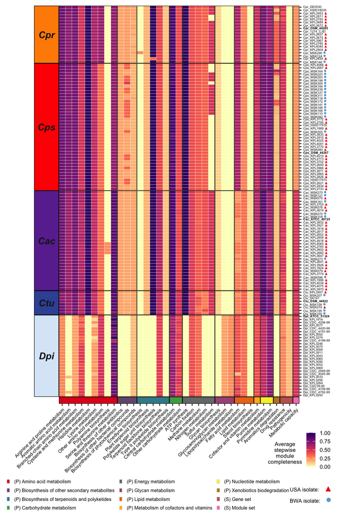

```r
# Final figure
Figure <- ggarrange(plot + theme(plot.margin = unit(c(0.5,0,1.5,3), "lines")),
                    ggarrange(
                      as_ggplot(get_legend(legend)) + theme(plot.margin = unit(c(-1,0,1,2), "lines")),
                      as_ggplot(text.p) + theme(plot.margin = unit(c(0,0,2,1.5), "lines")),
                      nrow = 1, widths = c(0.8,0.2)),
                    nrow = 2, heights = c(1,0.02))
Figure
```

```r
ggsave(plot = Figure, filename = "data/Anvio8/Metabolic_Analysis/Fig_Tables/CorPGA_Heatmap.png", height = 9, width = 6, device = 'png', dpi = 600)
ggsave(plot = Figure, filename = "data/Anvio8/Metabolic_Analysis/Fig_Tables/CorPGA_Heatmap.svg", height = 9, width = 6, device = 'svg', dpi = 600)
```

#### 3.4.3.1 Percentages in Figure 9

```r
Modules_MeansSummary = Modules_Means %>%
  group_by(modules_final_label, species_name, .drop = TRUE) %>%
  summarise(mean_bySpecies = mean(mean_stepwise_module_completeness))
```

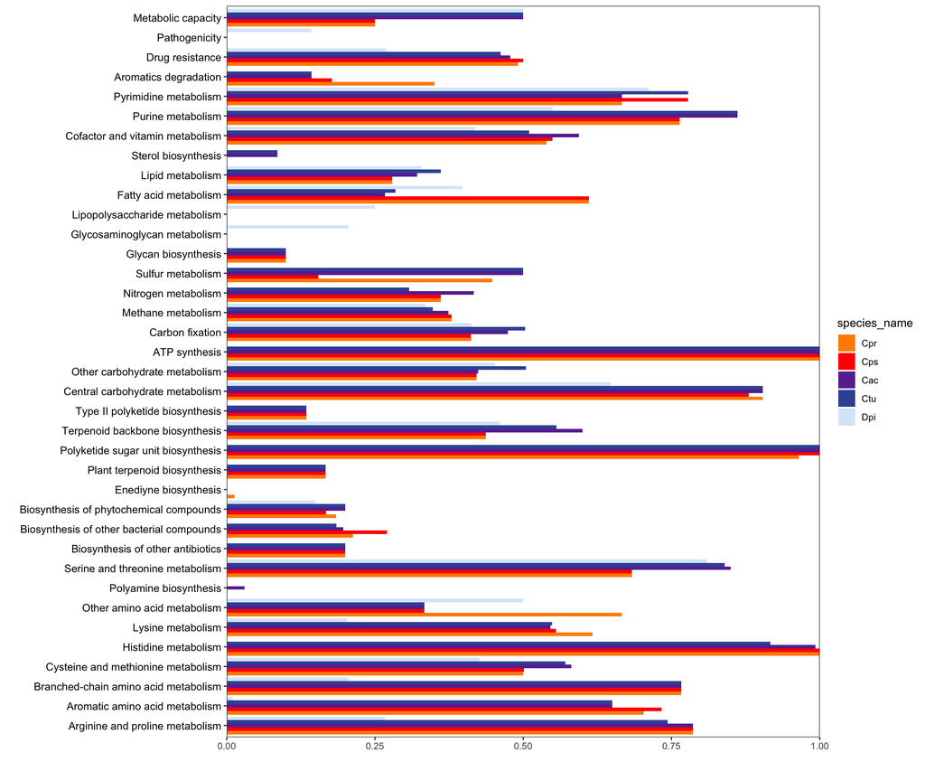

```r
summaryPlot <- ggplot(Modules_MeansSummary, aes(x = mean_bySpecies, y = modules_final_label, fill = species_name)) +
  geom_bar(stat = "identity", position = "dodge") +
  scale_fill_manual(values = colorsSpecies) +
  scale_x_continuous(expand = c(0,0)) +
  labs(x = "", y = "") +
  theme_bw() +
  theme(panel.grid.major = element_blank(),
        panel.grid.minor = element_blank(),
        axis.text.y = element_text(hjust = 1, size = 10, color = "black"))
summaryPlot
```

```r
saveWidget(ggplotly(summaryPlot), "data/Anvio8/Metabolic_Analysis/Fig_Tables/Heatmap_Percents_Interactive.html", selfcontained = TRUE)
```

### 3.4.4 Figure 6A

This code uses `BEDTools` (Quinlan, 2014; Quinlan and Hall, 2010) to extract annotations and sequences for the *fpr* to *hchA* region for all *C. pseudodiphtheriticum* genomes:

```bash
path_i="data/Anvio8/Prokka_out"
path_o="data/Anvio8/Metabolic_Analysis/Fig_Tables/Alignment_hchA-fprA"
mkdir -p $path_o

gene_1="hchA"
gene_2="fprA"
species="Cps"
label="ASR_Cps_region"

fasta_files=()

for file in $path_i/$species*.gff; do
    filename=$(basename "$file")
    filename_noext="${filename%.*}"
    fasta_output="$path_o/${filename_noext}_region_sequence.fasta"

    awk '/^##FASTA/{flag=1;next} {if(!flag) print}' "$file" > "$path_o/${filename_noext}_annotations.gff"
    awk '/^##FASTA/{flag=1} {if(flag) print}' "$file" > "$path_o/${filename_noext}_sequence_temp.fasta"
    grep -v '^##FASTA' "$path_o/${filename_noext}_sequence_temp.fasta" > "$path_o/${filename_noext}_sequence.fasta"
    rm "$path_o/${filename_noext}_sequence_temp.fasta"

    grep -E 'Name='$gene_1'|Name='$gene_2 "$path_o/${filename_noext}_annotations.gff" | sort -k4,4n | awk 'NR==1 {start=$4} NR==2 {end=$5} END {print $1 "\t" start "\t" end}' > "$path_o/${filename_noext}_region_coordinates.bed"
    bedtools intersect -a "$path_o/${filename_noext}_annotations.gff" -b "$path_o/${filename_noext}_region_coordinates.bed" -wa > "$path_o/${filename_noext}_region_annotations.gff"
    bedtools getfasta -fi "$path_o/${filename_noext}_sequence.fasta" -bed "$path_o/${filename_noext}_region_coordinates.bed" | awk -v filename="$filename_noext" '/^>/ {print ">" filename "|" substr($0, 2)} !/^>/' > "$fasta_output"

    fasta_files+=("$fasta_output")
done
```

We use MAFFT (Katoh, 2002; Katoh and Standley, 2013) to align the extracted sequences.

```bash
#conda activate mafft

cat "${fasta_files[@]}" > "$path_o/$label.fasta"
mafft --adjustdirection --reorder "$path_o/$label.fasta" > "$path_o/${label}_align.fasta"
sed 's/|.*//;s/_R_//' "$path_o/${label}_align.fasta" > "$path_o/${label}_align_clean.fasta" #Clean up header names
```

We used AliView (Larsson, 2014) to inspect the output file and to reverse complement the alignment to match the operon order. We saved the reversed complemented version of the alignment as `ASR_Cps_region_align_clean_R.fasta`.

Next we count the alignment length and create a reference sequence with all Ns and header named “Genes”. This will be used as a base for gene labeling and as a reference so visualize only the gaps to the consensus.

```bash
count=$(awk 'NR==2 {print length($0)}' "$path_o/${label}_align_clean_R.fasta")
filename="$path_o/${label}_reference.fasta"

echo ">Genes" >> "$filename"
echo "$(printf 'N%.0s' $(seq 1 $count))" >> "$filename"
cat "$path_o/${label}_reference.fasta" "$path_o/${label}_align_clean_R.fasta" > "$path_o/${label}_align_clean_R_Ref.fasta"

echo ">-----------Genes" > "$filename"
echo "$(printf 'N%.0s' $(seq 1 $count))" >> "$filename"
echo ">" >> "$filename"
echo "$(printf '-%.0s' $(seq 1 $count))" >> "$filename"
```

The version of the alignment file with the reference sequence is the input for the visualization with the `msavisr` package (Vragh, 2022).

```r
plot_ASR <- msavisr("data/Anvio8/Metabolic_Analysis/Fig_Tables/Alignment_hchA-fprA/ASR_Cps_region_align_clean_R_Ref.fasta",
                myref = "Genes",
                refontop = TRUE,
                basecolors = c("black","black","white"))

plot_ASR <- plot_ASR +
  theme(legend.position = "none",
        axis.title.x = element_blank(),
        axis.text.x = element_blank(),
        axis.ticks.x = element_blank(),
        axis.text.y = element_text(size = 14, color = "black"))

saveRDS(plot_ASR, "data/Anvio8/Metabolic_Analysis/Fig_Tables/Alignment_hchA-fprA/ASR_plot.rds")
```

This code creates a reference sequence with gene locations and length proportional to the corresponding gene coordinates to use as a label.

```r
#Manual list of gene coordinates generated by searching individual genes in the aligned fasta
genes <- list(c("-----------Genes", 11579:10901, "8_hchA"),
              c("-----------Genes", 8816:7815, "7_cysZ"),
              c("-----------Genes", 7806:6988, "6_cysY"),
              c("-----------Genes", 6971:5595, "5_cysN"),
              c("-----------Genes", 5595:4513, "4_cysD"),
              c("-----------Genes", 4516:3458, "3_cysH"),
              c("-----------Genes", 3461:1788, "2_cysI"),
              c("-----------Genes", 1424:1, "1_fpr2")
)

plot_ASRlabels <- msavisr("data/Anvio8/Metabolic_Analysis/Fig_Tables/Alignment_hchA-fprA/ASR_Cps_region_reference.fasta",
                myref = "-----------Genes",
                refontop = FALSE,
                basecolors = c("black","black","white"),
                myroi = genes, hroi = 1,
                roicolors = c("#9fd122","#00a84a","#f88502","#00a9f2","#6f88c9","#a94488","#c8c3e3", "gray80"))

# Values manually calculated to place the labels in the middle of each gene
plot_ASRlabels <- plot_ASRlabels +
  annotate("text", x = 678, y = 1, label = "fpr2", size = 7, fontface = 2) +
  annotate("text", x = 2624, y = 1, label = "cysI", size = 7, fontface = 2) +
  annotate("text", x = 3987, y = 1, label = "cysH", size = 7, fontface = 2) +
  annotate("text", x = 5054, y = 1, label = "cysD", size = 7, fontface = 2) +
  annotate("text", x = 6283, y = 1, label = "cysN", size = 7, fontface = 2) +
  annotate("text", x = 7397, y = 1, label = "cysY", size = 7, fontface = 2) +
  annotate("text", x = 8315, y = 1, label = "cysZ", size = 7, fontface = 2) +
  annotate("text", x = 11240, y = 1, label = "hchA", size = 7, fontface = 2) +
  theme(legend.position = "none",
        axis.title.x = element_blank(),
        axis.text.x = element_blank(),
        axis.ticks.x = element_blank(),
        axis.text.y = element_text(size = 12))
```

This generates the combined figure that was edited in Ilustrator for final edits, including adding symbols for the strains geographic location.

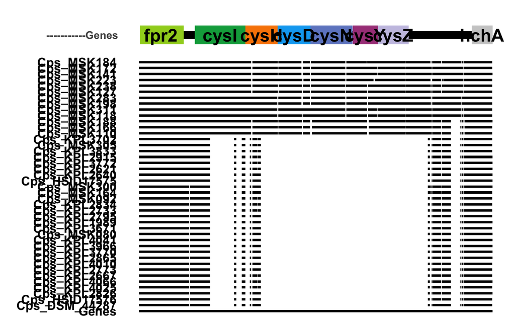

```r
plot_ASR <- readRDS("data/Anvio8/Metabolic_Analysis/Fig_Tables/Alignment_hchA-fprA/ASR_plot.rds")
FinalFigure <- ggarrange(plot_ASRlabels, plot_ASR, ncol = 1, heights = c(0.20, 1))
FinalFigure
```

```r
ggsave(FinalFigure, file = "data/Anvio8/Metabolic_Analysis/Fig_Tables/Alignment_hchA-fprA/ASR_Cps_region.svg", height = 10, width = 20, dpi = 150)
ggsave(FinalFigure, file = "data/Anvio8/Metabolic_Analysis/Fig_Tables/Alignment_hchA-fprA/ASR_Cps_region.png", height = 10, width = 20, dpi = 150)
```

## 3.5 GC level analysis

We performed pangenomic level analysis in 107 genomes: the 102 nasal *Corynebacterium* genomes selected for metabolic analysis (Cac_ATCC_49726 & Cps_090104 were excluded for this analysis) plus the 5 *Corynebacterium* listed in **Table S1D**:

- *Corynebacterium glutamicum* ATCC 13032 (Kyowa Hakko) ([GCF_000011325.1](https://www.ncbi.nlm.nih.gov/nuccore/NC_003450.3))
- *Corynebacterium diphtheriae* NCTC11397 ([GCF_001457455.1](https://www.ncbi.nlm.nih.gov/nuccore/983357513))
- *Corynebacterium simulans* PES1 ([GCF_001586215.1](https://www.ncbi.nlm.nih.gov/nuccore/1011117755))
- *Corynebacterium kroppenstedtii* DSM 44385 ([GCF_000023145.1](https://www.ncbi.nlm.nih.gov/nuccore/237784637))
- *Corynebacterium amycolatum* FDAARGOS_1108 ([GCF_016728725.1](https://www.ncbi.nlm.nih.gov/nuccore/1959980970))

```bash
#conda activate anvio-dev

path_i="data/Anvio8/Pangenomic_Analysis"

anvi-gen-genomes-storage -e "data/genome_lists/CorPGA_Anvio_GenomeList_v01c.txt" -o $path_i/CorPGA-All4CorRefs-GENOMES.db --gene-caller Prodigal

anvi-db-info $path_i/CorPGA-All4CorRefs-GENOMES.db

anvi-pan-genome -g $path_i/CorPGA-All4CorRefs-GENOMES.db \
                -o $path_i/All4CorRefs -n PAN_All4CorRefs \
                --use-ncbi-blast --mcl-inflation 10  --num-threads 8 --I-know-this-is-not-a-good-idea
```

Create a bin collection named All4CorRefs with all Core GCs for all the *Corynebacterium* species using the visual interface. We do this because in order to use `anvi-summarize` we need to have at least one bin.

```bash
#conda activate anvio-dev

path_i="data/Anvio8/Pangenomic_Analysis"

anvi-display-pan -p $path_i/All4CorRefs/PAN_All4CorRefs-PAN.db -g $path_i/CorPGA-All4CorRefs-GENOMES.db

anvi-summarize -p $path_i/All4CorRefs/PAN_All4CorRefs-PAN.db \
               -g $path_i/CorPGA-All4CorRefs-GENOMES.db \
               -o $path_i/All4CorRefs/Summaries \
               -C All4CorRefs
```

# References

**Bateman, A.** (2000). [The pfam protein families database](https://doi.org/10.1093/nar/28.1.263). *Nucleic Acids Research* 28, 263–266.

**Buchfink, B., Xie, C. and Huson, D. H.** (2014). [Fast and sensitive protein alignment using DIAMOND](https://doi.org/10.1038/nmeth.3176). *Nature Methods* 12, 59–60.

**Delmont, T. O. and Eren, A. M.** (2018). [Linking pangenomes and metagenomes: the *Prochlorococcus* metapangenome](https://doi.org/10.7717/peerj.4320). *PeerJ* 6, e4320.

**Drula, E., Garron, M.-L., Dogan, S., Lombard, V., Henrissat, B. and Terrapon, N.** (2021). [The carbohydrate-active enzyme database: functions and literature](https://doi.org/10.1093/nar/gkab1045). *Nucleic Acids Research* 50, D571–D577.

**Eddy, S. R.** (2011). [Accelerated Profile HMM Searches](https://doi.org/10.1371/journal.pcbi.1002195). *PLoS Computational Biology* 7, e1002195.

**Eren, A. M., Kiefl, E., Shaiber, A., Veseli, I., Miller, S. E., Schechter, M. S., Fink, I., Pan, J. N., Yousef, M., Fogarty, E. C., et al.** (2020). [Community-led, integrated, reproducible multi-omics with anvi’o](https://doi.org/10.1038/s41564-020-00834-3). *Nature Microbiology* 6, 3–6.

**Flores Ramos, S., Brugger, S. D., Escapa, I. F., Skeete, C. A., Cotton, S. L., Eslami, S. M., Gao, W., Bomar, L., Tran, T. H., Jones, D. S., et al.** (2021). [Genomic Stability and Genetic Defense Systems in*Dolosigranulum pigrum*, a Candidate Beneficial Bacterium from the Human Microbiome](https://doi.org/10.1128/msystems.00425-21). *mSystems* 6,.

**Galperin, M. Y., Wolf, Y. I., Makarova, K. S., Vera Alvarez, R., Landsman, D. and Koonin, E. V.** (2020). [COG database update: focus on microbial diversity, model organisms, and widespread pathogens](https://doi.org/10.1093/nar/gkaa1018). *Nucleic Acids Research* 49, D274–D281.

**Kanehisa, M.** (2000). [KEGG: Kyoto encyclopedia of genes and genomes](https://doi.org/10.1093/nar/28.1.27). *Nucleic Acids Research* 28, 27–30.

**Kanehisa, M., Furumichi, M., Sato, Y., Kawashima, M. and Ishiguro-Watanabe, M.** (2022). [KEGG for taxonomy-based analysis of pathways and genomes](https://doi.org/10.1093/nar/gkac963). *Nucleic Acids Research* 51, D587–D592.

**Katoh, K.** (2002). [MAFFT: A novel method for rapid multiple sequence alignment based on fast fourier transform](https://doi.org/10.1093/nar/gkf436). *Nucleic Acids Research* 30, 3059–3066.

**Katoh, K. and Standley, D. M.** (2013). [MAFFT Multiple Sequence Alignment Software Version 7: Improvements in Performance and Usability](https://doi.org/10.1093/molbev/mst010). *Molecular Biology and Evolution* 30, 772–780.

**Larsson, A.** (2014). [AliView: a fast and lightweight alignment viewer and editor for large datasets](https://doi.org/10.1093/bioinformatics/btu531). *Bioinformatics* 30, 3276–3278.

**Mistry, J., Chuguransky, S., Williams, L., Qureshi, M., Salazar, G., Sonnhammer, E. L. L., Tosatto, S. C. E., Paladin, L., Raj, S., Richardson, L. J., et al.** (2020). [Pfam: The protein families database in 2021](https://doi.org/10.1093/nar/gkaa913). *Nucleic Acids Research* 49, D412–D419.

**Quinlan, A. R.** (2014). [BEDTools: The Swiss-Army Tool for Genome Feature Analysis](https://doi.org/10.1002/0471250953.bi1112s47). *Current Protocols in Bioinformatics* 47,.

**Quinlan, A. R. and Hall, I. M.** (2010). [BEDTools: a flexible suite of utilities for comparing genomic features](https://doi.org/10.1093/bioinformatics/btq033). *Bioinformatics* 26, 841–842.

**Rückert, C., Koch, D. J., Rey, D. A., Albersmeier, A., Mormann, S., Pühler, A. and Kalinowski, J.** (2005). [Functional genomics and expression analysis of the Corynebacterium glutamicum fpr2-cysIXHDNYZ gene cluster involved in assimilatory sulphate reduction](https://doi.org/10.1186/1471-2164-6-121). *BMC Genomics* 6,.

**Shaiber, A., Willis, A. D., Delmont, T. O., Roux, S., Chen, L.-X., Schmid, A. C., Yousef, M., Watson, A. R., Lolans, K., Esen, Ö. C., et al.** (2020). [Functional and genetic markers of niche partitioning among enigmatic members of the human oral microbiome](https://doi.org/10.1186/s13059-020-02195-w). *Genome Biology* 21,.

**Tatusov, R. L.** (2000). [The COG database: A tool for genome-scale analysis of protein functions and evolution](https://doi.org/10.1093/nar/28.1.33). *Nucleic Acids Research* 28, 33–36.

**Veseli, I., Chen, Y. T., Schechter, M. S., Vanni, C., Fogarty, E. C., Watson, A. R., Jabri, B., Blekhman, R., Willis, A. D., Yu, M. K., et al.** (2023). [Microbes with higher metabolic independence are enriched in human gut microbiomes under stress](http://dx.doi.org/10.1101/2023.05.10.540289). *biorxiv*.

**Vragh** (2022). *[Vragh/seqvisr: v0.2.7](https://doi.org/10.5281/ZENODO.6583980)*. Zenodo.

[figure not shown]